# Assignment 1: Interactive Visualization

CMSC471: Introduction to Information Visualization (Spring 2026)

**Due**: March 8, 2026, 11:59 PM EST  
**Submission**:

- **Webpage**: Your interactive visualization and write-up.
- **Demo link**: URL submitted to Canvas-ELMS.
- **Video**: A brief demo video submitted to Canvas-ELMS.

**Grader**: Taehyun Yang

**Group policy**: **2-3 students**. Collaboration is an essential part of learning, and group work helps develop the communication and teamwork skills crucial for your future career. Working solo may limit these learning opportunities, so **a 10% penalty** will be applied unless you provide a compelling reason with supporting evidence. Note that difficulties with team management alone do not qualify as a valid justification.

## Introduction

Interactive visualizations do more than display data — they invite users to explore hidden stories and patterns. In this assignment, you will act as both designer and developer, creating an interactive tool that makes data exploration intuitive, engaging, and insightful.

The goal of this assignment is to gain familiarity implementing interaction techniques for visualizations. For example, the [zipdecode](https://benfry.com/zipdecode/) and [NameVoyager](https://web.archive.org/web/20211107232302/https://www.babynamewizard.com/namevoyager-expert) applications shown in class apply the interactive technique of dynamic queries – as explored in the earlier HomeFinder application – to the problem of uncovering patterns in zip codes and baby names. Similarly, [treemaps](https://www.cs.umd.edu/hcil/treemap/) were originally developed to display hierarchical file structure, and were later adapted to the problem of interactively depicting [a map of the stock market](https://www.bewitched.com/marketmap.html). We have seen many examples of interactive visualization techniques in class. The goal with this assignment is not only for you to gain hands-on implementation experience, but also for you to think about the effectiveness of the specific techniques for your chosen data.

## What you’ll do

Your task is to design and implement **a web-based interactive visualization** (this could be multiple smaller visualizations) for a dataset of your choice. Aim at enabling understanding of a compelling question for a dataset of your own choosing. In order to determine what subset of the data and which interactive options are most promising, you may want to perform additional exploratory analysis. What aspects of the data reveal the most interesting discoveries or stories? Do not feel obligated to try to convey everything about the data: focus on **a compelling subset**. You’ll explore design questions like:

- What story or insight does this dataset show?
- How can users interact with the visualization to uncover that story?
- Which techniques best facilitate exploration and understanding?
- Which aspects of the dataset are the most compelling?
- What visual encodings and interaction techniques suit your data and audience?

To get up and running quickly with this assignment, we ask you to explore one of the following provided datasets:

- [**Chicago Crimes, 2001–present**](https://data.cityofchicago.org/stories/s/Crimes-2001-to-present-Dashboard/5cd6-ry5g) (scroll down, click on the three dots to download a CSV file). This dataset reflects reported incidents of crime (with the exception of murders where data exists for each victim) that occurred in the City of Chicago from 2001 to present, minus the most recent seven days. Data is extracted from the Chicago Police Department’s CLEAR (Citizen Law Enforcement Analysis and Reporting) system. Note: you don’t have to show a map.
- [**Daily Weather in the U.S., 2017**](https://fumeng-yang.github.io/CMSC471/handouts/weather.csv). This dataset contains daily U.S. weather measurements in 2017, provided by the NOAA Daily Global Historical Climatology Network. This data has been transformed: some weather stations with only sparse measurements have been filtered out. See the accompanying weather.txt for descriptions of each column.
- [**Social mobility in the U.S.**](https://opportunityinsights.org/data/). Raj Chetty’s group at Harvard studies the factors that contribute to (or hinder) upward mobility in the United States (i.e., will our children earn more than we will). Their work has been [extensively featured in The New York Times](https://www.nytimes.com/search?query=raj%20chetty). This page lists data from all of their papers, broken down by geographic level or by topic. We recommend downloading data in the CSV/Excel format, and encourage you to consider joining multiple datasets from the same paper (under the same heading on the page) for a sufficiently rich exploratory process.

## Required elements

### 1. Web-based Interactive visualization

The goal is not to create an overwhelming visualization but a focused, elegant, and intuitive design. You will implement at least **one** interaction from **each** category:

Category I: Connection/Filtering

- Brushing and linking
- Dynamic filters or queries (Link by tuple/query)

Category II: Exploration/Selection/Abstraction/Elaboration/Encoding

- Panning and/or zooming.
- Details-on-demand (e.g., tooltips).
- Highlighting, annotation.
- Other narrative features intended to draw attention to particular items of interest and provide additional context.

We expect most students will use **D3.js** for this assignment; however, you are free to use other web-based libraries (e.g., Vega, Plotly, Shinny, etc). Your program should not require customized server-side support; you should simply load data from a static data file (csv, json, etc.).

### 2. Write-ups on your webpage

Include **a brief, clear write-up** on your webpage:

- **A brief introduction to your dataset**, background and your chosen variable(s) or subset.
- **Rationale for your design decisions**. List your implemented interactions. Explain: How did you choose your particular visual encodings and interaction techniques? What alternatives did you consider and how did you arrive at your ultimate choices?
- **References to data resources**. Be sure to list the data source you used. If your work adapts or builds on existing visualization examples, please cite those as well.
- **An overview of your development process**. Describe how the work was split among the team members. Include a commentary on the development process, including answers to the following questions: Roughly how much time did you spend developing your application (in people-hours)? What aspects took the most time?
- If any: A brief summary of AI (e.g. ChatGPT, Cursor, Codex) usage.

### 3. Public webpage

Deploy your visualization on a publicly accessible webpage. There are several ways to do this—the easiest is to use GitHub to host your project repository (see https://pages.github.com/). We also include details on how we publicized a lab at the end of this handout.

### 4. Record a demo video

The main purpose of this video is to provide a timestamp for your project demo (to prevent major changes after the deadline). It doesn’t need to be polished or have a professional voiceover, but it should be short (a few minutes), functional, and clearly showcase the features you’ve implemented. A casual voiceover is encouraged but not required.

## Checklist

Register your team on Canvas (use **A1** groups).  
Design **an interactive visualization** (could multiple smaller visualizations) with required interaction techniques.  
Deploy your visualization on as a webpage.  
Make sure your visualization has labels and captions.  
Include **a brief write-up** with references on your webpage.  
Submit **your webpage URL** to Canvas-ELMS.  
Submit **a short demo video** to Canvas-ELMS.

[figure not shown]

Team registration

## Grading rubric

Your project will be evaluated on the following dimensions out of 130 points. However, because **the web URL** and **the video** are important for grading, make sure you have all of them. Submissions that are substantially similar to your Labs 4-5 (without extra features) will receive approximately 80%.

| Component | Excellent | Good | Poor |
| --- | --- | --- | --- |
| **Interactive design** (25%) | Includes multiple required interactions (e.g., brushing, zooming, panning, selecting, highlighting) that enhance user engagement and exploration. Interactions are intuitive and smooth. | Includes basic interactions that enable exploration. Some interactions may lack polish or clarity. | Few or no interactive features. Interactions are confusing or unhelpful. |
| **Visualization design** (25%) | Uses effective visual encodings and thoughtful design principles. Clearly communicates key insights and supports user tasks. | Uses basic visual encodings with some effectiveness. May have minor design flaws or unclear elements. | Poor visual encodings that hinder understanding. Lacks coherence or focus. |
| **Implementation** (20%) | Fully functional code with robust performance and no noticeable bugs. | Mostly functional code with minor issues. | Significant errors or bugs that impair functionality. |
| **Write-up** (20%) | Thorough explanation of implemented interactions, design decisions, data sources, and process. Insightful reflections on challenges and successes. | Lists implemented interactions. Adequate explanation with minor gaps or limited detail. Reflections are somewhat superficial. | Incomplete or unclear explanation. Missing details or no reflections. |
| **Demo video** (10%) | Clearly shows all implemented features in a short, functional recording. | Demonstrates most key features but may have minor gaps or unclear moments. | Incomplete, unclear, or fails to show core functionalities. |

## Extra credits

Extra credit is awarded for work that **meaningfully goes beyond** the required elements. It is **not automatic** and is evaluated conservatively. We grade based on **quality and intent**, not quantity. Undocumented features will not receive extra credit. We have two categories of extra credit: **declared extra credit features** and **AI usage and equity**.

### Declaring extra credit features

If you aim for extra credit, include a clearly labeled **Extra Credit Features** section in your Canvas submission. Briefly explain: what the feature is, why it is innovative or advanced, and how it goes beyond the requirements. **Up to 13 points** may be awarded.

Features that are declared but not approved will simply be graded as part of the base assignment (no penalty).

### AI usage and equity

Using AI tools (e.g., ChatGPT, Copilot, Cursor) is **allowed but not required**. Not using AI will **not** disadvantage you.

AI-related extra credit (up to 6 points) is awarded **only** when AI is used in a **novel, reflective, and well-documented way** (e.g., supporting design exploration, interaction ideas, or user experience). Pure code generation alone does **not** qualify.

Students who choose not to use AI can earn extra credit through **non-AI innovation** (interaction design, visual encoding, narrative structure, etc.).

## How we publicized Lab 3

1. We create a new, public repository (e.g., `CMSC471-Lab3`).

[figure not shown]

create a repository

2. Then clone the repository to a local folder, and copy your code into the folder. Note the `index.html` must be at the top level of this folder.

```
CMSC471-Lab3/
├── index.html
├── css/
│   └── styles.css
├── js/
│   └── script.js
└── data/
    └── data.json
```

[figure not shown]

clone a repository

3. Push your code to GitHub.

[figure not shown]

push code to GitHub

4. We need to set up the GitHub pages. Click on `Settings` and then `Pages`. Choose the appropriate branch (e.g., `main`).

[figure not shown]

Set up Github pages

5. Then you can assess your page at `[github username].github.io/[project name]` (e.g., https://fumeng-yang.github.io/CMSC471-Lab3/). It may take up to 10 minutes (according to GitHub) or a few hours (my experience sometimes) for the page to show up.

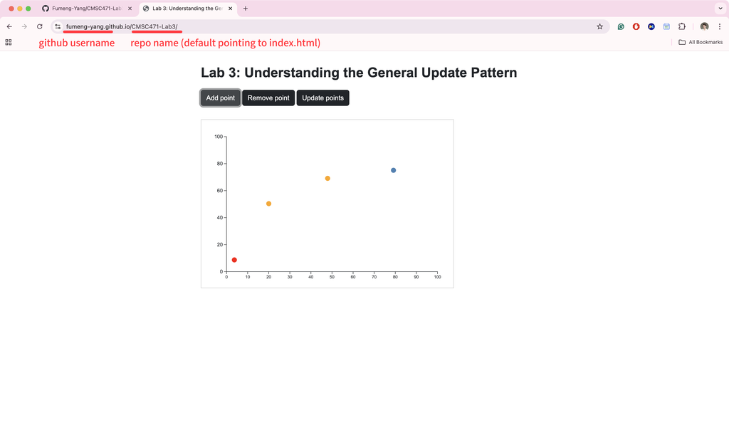

Visit your project page

When the page is alive, you can find a confirmation under the `Pages` tab.

[figure not shown]

Deployment confirmation

**Deployment tips**

1. Try a deployment early (e.g., at least a couple of days before the deadline).
2. You can start with a private repository, and then turn it into a public repository.
3. If data fails to load, check your file paths.